# Project Luther - Analysis

```python
import numpy as np
import pandas as pd

import dateutil.parser
import datetime
from datetime import timedelta
import math
import calendar

import statsmodels.api as sm
import statsmodels
import seaborn as sns
from numpy import linalg
import patsy

from sklearn.preprocessing import StandardScaler

from sklearn.linear_model import LinearRegression
from sklearn import metrics

from sklearn import feature_selection as f_select

from sklearn.preprocessing import PolynomialFeatures
from sklearn.pipeline import make_pipeline
from sklearn.linear_model import Ridge
from sklearn.linear_model import Lasso

from sklearn.model_selection import KFold
from sklearn.model_selection import cross_val_score
from sklearn.model_selection import cross_validate
from sklearn.model_selection import train_test_split
from sklearn.model_selection import learning_curve
from sklearn.model_selection import ShuffleSplit

from pymongo import MongoClient

from statsmodels.formula.api import ols

import matplotlib.pyplot as plt

import yellowbrick as yb
from yellowbrick.regressor.residuals import ResidualsPlot

%matplotlib inline
```

## Pull in scraped data

### Data Import

The data from our scraping resides in a Mongo database.

Let's go get it...

```python
client = MongoClient()
db = client.willco
```

```python
df = pd.DataFrame(
    list(db.PropertyInfo.find())
)
```

Pulling from Mongo doesn't automatically set NaN the way read_csv does.

So, let's take care of that here.

```python
df.replace('N/A',np.NaN,inplace=True)
df.shape
```

```
(59570, 35)
```

Pulling from Mongo orders columns alphabetically (and adds an ID column). Reorganizing the data columns to be more in line with how it's presented on the website...

```python
df = df[[
    'PIN', 'PropClass', 'Address', 'City', 'Zip', 'SaleDate', 'SaleAmt',
    'TaxRate', 'ASL', 'ASFL', 'AI', 'ASB', 'ASFB', 'ASTotal', 'ASFTotal',
    'Subdivision', 'FullBath', 'Style', 'HalfBath', 'LivingSqFt', 'CentralAir',
    'BldgSqFt', 'Fireplace', 'YearBuilt', 'Porch', 'Basement', 'Attic',
    'Garage', 'Lot', 'Block', 'Unit', 'Building', 'Area', 'Status'
]]
```

```python
df.head()
```

|  | PIN | PropClass | Address | City | Zip | SaleDate | SaleAmt | TaxRate | ASL | ASFL | ... | Porch | Basement | Attic | Garage | Lot | Block | Unit | Building | Area | Status |
| --- | --- | --- | --- | --- | --- | --- | --- | --- | --- | --- | --- | --- | --- | --- | --- | --- | --- | --- | --- | --- | --- |
| 0 | 04-10-01-101-001-0000 | COMMERCIAL | 2800 SCHWEITZER RD | JOLIET | 60421 | NaN | NaN | 8.5817 (2016) | 41,990 | 0 | ... | NO | NONE | NO | NONE | 1 | NaN | NaN | NaN | NaN | NaN |
| 1 | 05-06-01-101-001-0000 | COMMERCIAL | 1202 ESSINGTON RD | JOLIET | 60435 | 10/19/1987 | $140,000 | 10.2841 (2016) | 149,410 | 0 | ... | NO | ??? | NO | ATTACHED | NaN | NaN | NaN | NaN | NaN | NaN |
| 2 | 01-24-02-100-001-0000 | FARMING | 32801 S WEST RIVER RD | WILMINGTON | 60481 | NaN | NaN | 6.1960 (2016) | 6,331 | 47,103 | ... | NaN | NaN | NaN | NaN | NaN | NaN | NaN | NaN | NaN | NaN |
| 3 | 01-24-03-100-003-0000 | RESIDENTIAL | S RT 53 | WILMINGTON | 60481 | 01/01/2016 | $33,350 | 6.1960 (2016) | 1,657 | 0 | ... | NaN | NaN | NaN | NaN | NaN | NaN | NaN | NaN | NaN | NaN |
| 4 | 01-24-03-100-004-0000 | RESIDENTIAL | 32849 S RT 53 | WILMINGTON | 60481 | NaN | NaN | 6.1960 (2016) | 6,602 | 0 | ... | NaN | NaN | NaN | NaN | NaN | NaN | NaN | NaN | NaN | NaN |

5 rows × 34 columns

```python
df.shape
```

```
(59570, 34)
```

### Initial selections

We've scraped more data than we need. Let's pare it down...

#### Focus on Residential only

```python
df.PropClass.value_counts()
```

```
RESIDENTIAL    52794
FARMING         2102
OTHER           1985
COMMERCIAL      1730
INDUSTRIAL       959
Name: PropClass, dtype: int64
```

```python
df = df[df['PropClass'] == 'RESIDENTIAL']
```

#### Remove rows with no target data

```python
#df = df[df['SaleDate'].notnull()]
df.dropna(subset=['SaleDate'],inplace=True)
df.shape
```

```
(43835, 34)
```

## Massage the Data

The data is stored in the format or fashion as it existed on the website. We need a number of transformations in order to get the data where we can use it.

### Encapsulate the changes in a function

```python
df['Section'] = df['PIN'].apply(lambda x: x[:8])
```

```python
gx=df.groupby('Section').count()['PIN']
gx[df.tail().Section]
gx['06-03-35']
```

```
804
```

```python
def masseuse(data):
    ''' Initial field transformations to facilitate further analysis
    Input: data - the dataframe
    Changes are made in place.
    '''

    data['Section'] = data['PIN'].apply(lambda x: x[:8])
    gx = data.groupby('Section').count()['PIN']
    data['Density'] = data['Section'].apply(lambda x: gx[x]).astype(float)

    data['SaleDate'] = data['SaleDate'].apply(lambda x: dateutil.parser.parse(x))

    data['Longevity'] = data['SaleDate'].apply(lambda x: dateutil.parser.parse('2018-01-01') - x)

    data['Longevity']=data['Longevity'].apply(lambda x: x.total_seconds()/86400.)

    data['SaleAmt']=data['SaleAmt'].replace('[\$,]', '', regex=True).astype(float)

    data['TaxRate']=data['TaxRate'].replace('\(\d+\)', '', regex=True).astype(float)

    data['ASTotal']=data['ASTotal'].replace('[,]', '', regex=True).astype(float)

    data['ASFTotal']=data['ASFTotal'].replace('[,]', '', regex=True).astype(float)

    data['LivingSqFt']=data['LivingSqFt'].replace(' Sq. Feet', '', regex=True).astype(float)

    data['BldgSqFt']=data['BldgSqFt'].replace(' Sq. Feet', '', regex=True).astype(float)

    data['YearBuilt'] = data['YearBuilt'].astype(float)
    data['FullBath'] = data['FullBath'].astype(float)
    data['HalfBath'] = data['HalfBath'].astype(float)

    data['CentralAir'].replace('YES',1.,inplace=True)
    data['CentralAir'].replace('NO',0.,inplace=True)
    data['CentralAir'] = data['CentralAir'].astype(float)

    data['Fireplace'].replace('YES',1.,inplace=True)
    data['Fireplace'].replace('NO',0.,inplace=True)
    data['Fireplace'] = data['Fireplace'].astype(float)

    data['Porch'].replace('YES',1.,inplace=True)
    data['Porch'].replace('NO',0.,inplace=True)
    data['Porch'] = data['Porch'].astype(float)
```

### Implement the Changes

```python
masseuse(df)
```

## Prepare to Model

### Select rows with data for all chosen features

For the most part, the records available from our data source either has complete information or a portion of the information is simply marked unavailable. Therefore, when this portion of data is missing for a feature, it's likely missing for the same set of features.

```python
df2 = df[[
    'Longevity',
    'SaleAmt',
    'TaxRate',
    'ASTotal',
    'LivingSqFt',
    'YearBuilt',
    'FullBath',
    'HalfBath',
    'Fireplace',
    'CentralAir',
    'Porch',
    'Section',
    'Density'
]]
df2=df2[df2.notnull().all(axis=1)]
df2.shape
```

```
(33338, 13)
```

### Outlier Treatment

Earlier exploration with smaller datasets showed that a number of our features have significant outliers. Switching to log helped to capture the data better but there were still outliers.

#### Exploration

The primary features to treat here are:

- SaleAmt
- ASTotal
- LivingSqFt

We could do the same for a few other fields. But there are a number of "sets" or groupings of these features. Of these, I've chosen one rather than continue with the colinearity issues. For example, I'm using LivingSqFt and ignoring BldgSqFt.

##### Preparation

```python
df2 = df2[
    (df2['SaleAmt'] != 0) &
    (df2['LivingSqFt'] != 0) &
    (df2['ASTotal'] != 0)
]
df2.shape
```

```
(30306, 13)
```

```python
def explore_1(feature):
    fig=plt.figure(figsize=(15,4))
    ax = plt.subplot2grid((3, 2), (0, 0))
    bp = ax.boxplot(
        df2[feature],
        sym='+', vert=False, patch_artist=True)
    ax = plt.subplot2grid((3, 2), (0, 1))
    bp = ax.hist(
        df2[feature],
        bins=100
    )
    log_feature = np.log(df2[feature])
    ax = plt.subplot2grid((3, 2), (1, 0))
    bp = ax.boxplot(
        log_feature,
        sym='+', vert=False, patch_artist=True)
    ax = plt.subplot2grid((3, 2), (1, 1))
    bp = ax.hist(
        log_feature,
        bins=100
    )
    q75, q25 = np.percentile(log_feature, [75 ,25])
    iqr = q75 - q25
    lmin = q25 - (iqr*1.5)
    lmax = q75 + (iqr*1.5)
    log_trimmed = log_feature[log_feature > lmin]
    log_trimmed = log_trimmed[log_trimmed < lmax]
    ax = plt.subplot2grid((3, 2), (2, 0))
    bp = ax.boxplot(
        log_trimmed,
        sym='+', vert=False, patch_artist=True)
    ax = plt.subplot2grid((3, 2), (2, 1))
    bp = ax.hist(
        log_trimmed,
        bins=100
    )
```

##### Visualization

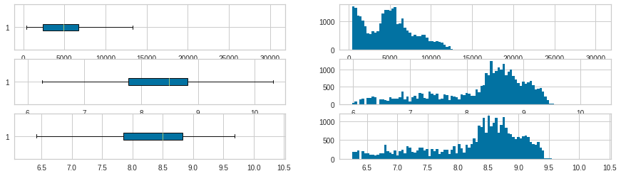

```python
explore_1('Longevity')
```

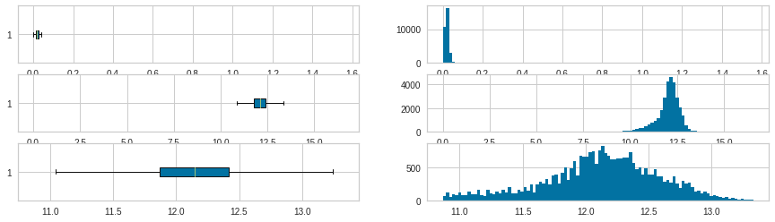

```python
explore_1('SaleAmt')
```

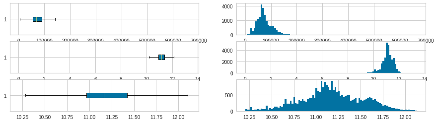

```python
explore_1('ASTotal')
```

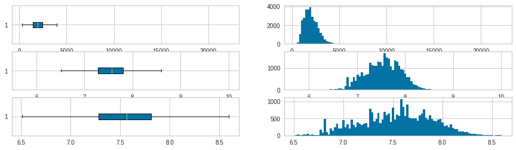

```python
explore_1('LivingSqFt')
```

#### Decisions

We can use patsy to do log transformation. But let's do it here so we can further apply IQR based removal

```python
for feature in ['SaleAmt','ASTotal','LivingSqFt','Longevity']:
    logf = 'Log_' + feature
    df2[logf] = np.log(df2[feature])
    q75, q25 = np.percentile(df2[logf], [75 ,25])
    iqr = q75 - q25
    lmin = q25 - (iqr*1.5)
    lmax = q75 + (iqr*1.5)
    df2 = df2[df2[logf]>lmin]
    df2 = df2[df2[logf]<lmax]
df2.shape
```

```
(27300, 17)
```

```python
# A quick cut here for prototyping...
df2 = df2[:1000]
```

### Prepare the Model

#### Review Correlations

```python
df2.corr().sort_values('Longevity')
```

|  | Longevity | SaleAmt | TaxRate | ASTotal | LivingSqFt | YearBuilt | FullBath | HalfBath | Fireplace | CentralAir | Porch | Density | Log_SaleAmt | Log_ASTotal | Log_LivingSqFt | Log_Longevity |
| --- | --- | --- | --- | --- | --- | --- | --- | --- | --- | --- | --- | --- | --- | --- | --- | --- |
| Log_SaleAmt | -0.324790 | 0.956075 | -0.202863 | 0.680784 | 0.586806 | 0.041859 | 0.054750 | 0.230793 | 0.299794 | 0.004714 | 0.139275 | -0.133594 | 1.000000 | 0.701641 | 0.588082 | -0.181865 |
| SaleAmt | -0.282381 | 1.000000 | -0.178728 | 0.745069 | 0.640559 | 0.042522 | 0.075237 | 0.258146 | 0.319281 | -0.042849 | 0.148568 | -0.173099 | 0.956075 | 0.731251 | 0.618274 | -0.155813 |
| CentralAir | -0.121918 | -0.042849 | 0.167145 | -0.161761 | 0.060385 | -0.015568 | -0.214047 | -0.157721 | -0.301008 | 1.000000 | -0.309217 | -0.085575 | 0.004714 | -0.132254 | 0.112910 | -0.084335 |
| LivingSqFt | -0.045015 | 0.640559 | 0.009063 | 0.773210 | 1.000000 | 0.033473 | 0.063043 | 0.268837 | 0.314672 | 0.060385 | 0.136709 | -0.223614 | 0.586806 | 0.748974 | 0.977233 | -0.001924 |
| Log_LivingSqFt | -0.040790 | 0.618274 | 0.029309 | 0.737280 | 0.977233 | 0.036480 | 0.054946 | 0.276854 | 0.301384 | 0.112910 | 0.135821 | -0.207039 | 0.588082 | 0.734685 | 1.000000 | 0.002972 |
| HalfBath | -0.040120 | 0.258146 | 0.175852 | 0.296385 | 0.268837 | 0.022763 | 0.422643 | 1.000000 | 0.138804 | -0.157721 | 0.291061 | -0.025319 | 0.230793 | 0.270424 | 0.276854 | -0.012412 |
| TaxRate | -0.037848 | -0.178728 | 1.000000 | -0.308856 | 0.009063 | -0.029393 | 0.261750 | 0.175852 | -0.080985 | 0.167145 | 0.043957 | 0.089073 | -0.202863 | -0.358858 | 0.029309 | -0.031492 |
| Density | -0.003588 | -0.173099 | 0.089073 | -0.211503 | -0.223614 | 0.033124 | 0.076763 | -0.025319 | -0.077688 | -0.085575 | 0.037000 | 1.000000 | -0.133594 | -0.183686 | -0.207039 | 0.010409 |
| YearBuilt | -0.003125 | 0.042522 | -0.029393 | 0.049635 | 0.033473 | 1.000000 | 0.017528 | 0.022763 | 0.079880 | -0.015568 | 0.039966 | 0.033124 | 0.041859 | 0.053942 | 0.036480 | 0.000731 |
| FullBath | 0.007991 | 0.075237 | 0.261750 | 0.115947 | 0.063043 | 0.017528 | 1.000000 | 0.422643 | 0.104505 | -0.214047 | 0.282449 | 0.076763 | 0.054750 | 0.093242 | 0.054946 | 0.014429 |
| ASTotal | 0.013636 | 0.745069 | -0.308856 | 1.000000 | 0.773210 | 0.049635 | 0.115947 | 0.296385 | 0.438262 | -0.161761 | 0.252863 | -0.211503 | 0.680784 | 0.976450 | 0.737280 | 0.045667 |
| Log_ASTotal | 0.021035 | 0.731251 | -0.358858 | 0.976450 | 0.748974 | 0.053942 | 0.093242 | 0.270424 | 0.440279 | -0.132254 | 0.247498 | -0.183686 | 0.701641 | 1.000000 | 0.734685 | 0.052105 |
| Fireplace | 0.072357 | 0.319281 | -0.080985 | 0.438262 | 0.314672 | 0.079880 | 0.104505 | 0.138804 | 1.000000 | -0.301008 | 0.300044 | -0.077688 | 0.299794 | 0.440279 | 0.301384 | 0.058021 |
| Porch | 0.091556 | 0.148568 | 0.043957 | 0.252863 | 0.136709 | 0.039966 | 0.282449 | 0.291061 | 0.300044 | -0.309217 | 1.000000 | 0.037000 | 0.139275 | 0.247498 | 0.135821 | 0.079053 |
| Log_Longevity | 0.927041 | -0.155813 | -0.031492 | 0.045667 | -0.001924 | 0.000731 | 0.014429 | -0.012412 | 0.058021 | -0.084335 | 0.079053 | 0.010409 | -0.181865 | 0.052105 | 0.002972 | 1.000000 |
| Longevity | 1.000000 | -0.282381 | -0.037848 | 0.013636 | -0.045015 | -0.003125 | 0.007991 | -0.040120 | 0.072357 | -0.121918 | 0.091556 | -0.003588 | -0.324790 | 0.021035 | -0.040790 | 0.927041 |

#### Define the model

```python
y, X = patsy.dmatrices('Log_Longevity ~ Log_SaleAmt + TaxRate + Log_ASTotal + Log_LivingSqFt + YearBuilt + Fireplace + CentralAir + Porch', data=df2, return_type="dataframe")
```

```python
X.head()
```

|  | Intercept | Log_SaleAmt | TaxRate | Log_ASTotal | Log_LivingSqFt | YearBuilt | Fireplace | CentralAir | Porch |
| --- | --- | --- | --- | --- | --- | --- | --- | --- | --- |
| 558 | 1.0 | 11.198215 | 7.8868 | 11.336510 | 7.271704 | 1949.0 | 1.0 | 1.0 | 0.0 |
| 589 | 1.0 | 12.691580 | 8.0742 | 11.577111 | 7.477604 | 1995.0 | 1.0 | 1.0 | 1.0 |
| 606 | 1.0 | 12.283034 | 8.9128 | 11.320869 | 7.451242 | 1979.0 | 1.0 | 1.0 | 0.0 |
| 607 | 1.0 | 11.492723 | 8.9128 | 11.343252 | 7.971776 | 1979.0 | 1.0 | 1.0 | 1.0 |
| 608 | 1.0 | 12.301383 | 8.9128 | 11.264977 | 7.614805 | 1978.0 | 1.0 | 1.0 | 1.0 |

#### Standardize

```python
X = StandardScaler().fit_transform(X)
```

## Model Experimentation and Evaluation

```python
y.mean()
```

```
Log_Longevity    8.246999
dtype: float64
```

### Basic Linear Regression

```python
reg = LinearRegression()
scores = cross_val_score(reg, X, y, cv=10, scoring='neg_mean_squared_error')

# scores output is negative, a sklearn quirk bc mse is used to min. optimization func.
print(np.array([math.sqrt(x) for x in -scores]))
```

```
[ 0.77782411  0.75733912  0.75356208  0.76513682  0.71110719  0.71484247
  0.71611499  0.73752505  0.76529421  0.76893407]
```

### Basic Polynomial Regression

```python
reg = LinearRegression()
degree=2
est = make_pipeline(PolynomialFeatures(degree), LinearRegression())
scores = cross_val_score(est, X, y, cv=10, scoring='neg_mean_squared_error')

# scores output is negative, a sklearn quirk bc mse is used to min. optimization func.
print(np.array([math.sqrt(x) for x in -scores]))
```

[output not shown]

```python
reg = LinearRegression()
scoring = ['neg_mean_squared_error', 'r2']
scores = cross_validate(reg, X, y, scoring=scoring,cv=10, return_train_score=True)
scores
```

```
{'fit_time': array([ 0.02397871,  0.00995731,  0.01100755,  0.01839995,  0.01383066,
         0.0111587 ,  0.00897789,  0.0065949 ,  0.0133121 ,  0.00609326]),
 'score_time': array([ 0.00095797,  0.0007441 ,  0.00128365,  0.00065398,  0.00082874,
         0.00080156,  0.00058365,  0.00255775,  0.0021584 ,  0.02351403]),
 'test_neg_mean_squared_error': array([-0.60501035, -0.57356254, -0.5678558 , -0.58543436, -0.50567344,
        -0.51099975, -0.51282068, -0.5439432 , -0.58567523, -0.5912596 ]),
 'test_r2': array([ 0.05880326,  0.03201669,  0.06040886,  0.04724393,  0.19900863,
         0.10479881,  0.10876697,  0.18902857,  0.04195548,  0.07636793]),
 'train_neg_mean_squared_error': array([-0.55017119, -0.55376059, -0.554242  , -0.55231256, -0.56147301,
        -0.56051199, -0.56033911, -0.55708868, -0.55240355, -0.55160644]),
 'train_r2': array([ 0.10442918,  0.10717405,  0.10447899,  0.10593538,  0.08691485,
         0.09981387,  0.09931987,  0.08834454,  0.10603413,  0.10297949])}
```

### Feature evaluation

```python
kf = KFold(n_splits=5, shuffle=True)


# create a linear regression model
lm = LinearRegression()
all_scores=[]

# get indices of corresponding train & test
for train,test in kf.split(X):
    x_train=X.iloc[train]
    y_train=y.iloc[train]
    x_test=X.iloc[test]
    y_test=y.iloc[test]

    pvals=[]
    sig_cols=[]

    # within each training set, find the significant variables
    for feature in x_train.columns:
        pval=f_select.f_regression(x_train[[feature]], y_train)

        if pval[1][0]<.01:
            sig_cols.append(feature)
            pvals.append(pval[1][0])

    lm.fit(x_train[sig_cols],y_train)
    print(sig_cols)

    r_2=lm.score(x_test[sig_cols],y_test)
    all_scores.append(r_2)

np.mean(all_scores)
```

[output not shown]

```
0.06713711141161946
```

### Ridge Regression

```python
alpha = 0.01
degree=2
est = make_pipeline(PolynomialFeatures(degree), Ridge(alpha=alpha))
scoring = ['neg_mean_squared_error', 'r2','neg_median_absolute_error']
scores = cross_validate(est, X, y, scoring=scoring,cv=10, return_train_score=True)
scores
```

[output not shown]

```python
scores['test_neg_median_absolute_error'].mean()/365
```

```
-4.9684234165931986
```

### Lasso Regression

```python
alpha = 100
degree=2
est = make_pipeline(PolynomialFeatures(degree), Lasso(alpha=alpha))
scoring = ['neg_mean_squared_error', 'r2']
scores = cross_validate(est, X, y, scoring=scoring,cv=10, return_train_score=True)
scores
```

[output not shown]

### Bias and Variance Evaluation

#### Homespun

First, my own attempt at developing this plot...

```python
def sample_test_train(N,k,size,seed=False):
    ''' Create a set of train/test samples.
        The goal here is random sets of a certain size.
        There is no intention of these sets being non-overlapping.
        Size is same for both test and train unless the requested
        size is more than half of the N provided.
        Input:
            N    the size of the data
            k    the number or samples desired
            size the size of the samples desired
        Output:
            List of pairs of list of indices
    '''
    if seed:
        np.seed(seed)
    output = []
    for i in range(k):
        indices = np.random.permutation(N)
        output.append([indices[:size],indices[size:min(size*2,N)]])
    return output
```

```python
def learning_plot(est,X,y,points=10,rep=10):
    """ Create a plot to visualize the learning of the model.
    Inputs:
        est    the estimator
        X      the features
        y      the target
        points the number of tests
        rep    the number of repetitions at each test size
    """
    x = np.arange(points)
    train_err = np.array([])
    test_err = np.array([])
    N = len(X)
    sizes = [math.ceil(0.9 * N * (1 + i)/points) for i in x]
    for size in sizes:
        train = np.array([])
        test = np.array([])
        for train_ind,test_ind in sample_test_train(len(X),rep,size):
            X_train = X.iloc[train_ind]
            X_test  = X.iloc[test_ind]
            y_train = y.iloc[train_ind]
            y_test  = y.iloc[test_ind]
            est.fit(X.iloc[train_ind],y.iloc[train_ind])
            train = np.append(train,
                metrics.mean_squared_error(
                    est.predict(X.iloc[train_ind]),
                    y.iloc[train_ind]
            ))
            test = np.append(test,
                metrics.mean_squared_error(
                    est.predict(X.iloc[test_ind]),
                    y.iloc[test_ind]
            ))
        train_err = np.append(train_err,train.mean())
        test_err = np.append(test_err,test.mean())
    plt.figure(figsize=(8,6))
    plt.scatter(sizes, train_err,c='b')
    plt.scatter(sizes, test_err,c='r')
```

[figure not shown]

```python
est = make_pipeline(LinearRegression())
learning_plot(est,X,y,20,100)
```

#### Using sklearn

```python
def plot_learning_curve(estimator, title, X, y, ylim=None, cv=None,
                        n_jobs=1, train_sizes=np.linspace(.1, 1.0, 5)):
    """
    Generate a simple plot of the test and training learning curve.

    Parameters
    ----------
    estimator : object type that implements the "fit" and "predict" methods
        An object of that type which is cloned for each validation.

    title : string
        Title for the chart.

    X : array-like, shape (n_samples, n_features)
        Training vector, where n_samples is the number of samples and
        n_features is the number of features.

    y : array-like, shape (n_samples) or (n_samples, n_features), optional
        Target relative to X for classification or regression;
        None for unsupervised learning.

    ylim : tuple, shape (ymin, ymax), optional
        Defines minimum and maximum yvalues plotted.

    cv : int, cross-validation generator or an iterable, optional
        Determines the cross-validation splitting strategy.
        Possible inputs for cv are:
          - None, to use the default 3-fold cross-validation,
          - integer, to specify the number of folds.
          - An object to be used as a cross-validation generator.
          - An iterable yielding train/test splits.

        For integer/None inputs, if ``y`` is binary or multiclass,
        :class:`StratifiedKFold` used. If the estimator is not a classifier
        or if ``y`` is neither binary nor multiclass, :class:`KFold` is used.

        Refer :ref:`User Guide <cross_validation>` for the various
        cross-validators that can be used here.

    n_jobs : integer, optional
        Number of jobs to run in parallel (default 1).
    """
    plt.figure()
    plt.title(title)
    if ylim is not None:
        plt.ylim(*ylim)
    plt.xlabel("Training examples")
    plt.ylabel("Score")
    train_sizes, train_scores, test_scores = learning_curve(
        estimator, X, y, cv=cv, n_jobs=n_jobs, train_sizes=train_sizes)
    train_scores_mean = np.mean(train_scores, axis=1)
    train_scores_std = np.std(train_scores, axis=1)
    test_scores_mean = np.mean(test_scores, axis=1)
    test_scores_std = np.std(test_scores, axis=1)
    plt.grid()

    plt.fill_between(train_sizes, train_scores_mean - train_scores_std,
                     train_scores_mean + train_scores_std, alpha=0.4,
                     color="r")
    plt.fill_between(train_sizes, test_scores_mean - test_scores_std,
                     test_scores_mean + test_scores_std, alpha=0.4, color="g")
    plt.plot(train_sizes, train_scores_mean, 'o-', color="r",
             label="Training score")
    plt.plot(train_sizes, test_scores_mean, 'o-', color="g",
             label="Cross-validation score")

    plt.legend(loc="best")
    return plt
```

```
<module 'matplotlib.pyplot' from '/home/joseph/anaconda3/lib/python3.6/site-packages/matplotlib/pyplot.py'>
```

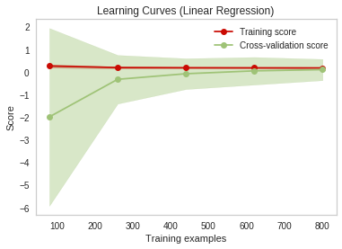

```python
est = make_pipeline(LinearRegression())

plot_learning_curve(
    est,
    "Learning Curves (Linear Regression)",
    X[:1000], y[:1000],
    cv = ShuffleSplit(n_splits=100, test_size=0.2),
    n_jobs=4,
    #ylim=(0.7, 1.01)
)
```

```
<module 'matplotlib.pyplot' from '/home/joseph/anaconda3/lib/python3.6/site-packages/matplotlib/pyplot.py'>
```

[figure not shown]

```python
est = make_pipeline(LinearRegression())

plot_learning_curve(
    est,
    "Learning Curves (Linear Regression)",
    X, y,
    cv = ShuffleSplit(n_splits=100, test_size=0.2),
    n_jobs=4,
    #ylim=(0.7, 1.01)
)
```

```
<module 'matplotlib.pyplot' from '/home/joseph/anaconda3/lib/python3.6/site-packages/matplotlib/pyplot.py'>
```

[figure not shown]

```python
alpha = 0.01
degree=2
est = make_pipeline(PolynomialFeatures(degree), Ridge(alpha=alpha))
plot_learning_curve(
    est,
    "Learning Curves (Ridge Regression)",
    X, y,
    cv = ShuffleSplit(n_splits=100, test_size=0.2),
    n_jobs=4,
    #ylim=(0.7, 1.01)
)
```

### Check for Homoscedasticity

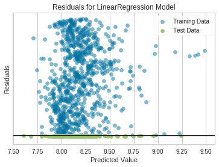

```python
est = make_pipeline(LinearRegression())
# Create the train and test data
X_train, X_test, y_train, y_test = train_test_split(X[:1000], y[:1000], test_size=0.2)

visualizer = ResidualsPlot(est)

visualizer.fit(X_train, y_train)  # Fit the training data to the visualizer
visualizer.score(X_test, y_test)  # Evaluate the model on the test data
visualizer.ax.get_yaxis().set_ticks([])
g = visualizer.poof()             # Draw/show/poof the data
```

[figure not shown]

```python
alpha = 0.01
degree=2
est = make_pipeline(PolynomialFeatures(degree), Ridge(alpha=alpha))
# Create the train and test data
X_train, X_test, y_train, y_test = train_test_split(X, y, test_size=0.2)

visualizer = ResidualsPlot(est)

visualizer.fit(X_train, y_train)  # Fit the training data to the visualizer
visualizer.score(X_test, y_test)  # Evaluate the model on the test data
g = visualizer.poof()             # Draw/show/poof the data
```